# SFPD Calls for Service_Feb 23,2020

Rob Wells

2/23/2020

### Reporting on Homelessness: Data Analysis for Journalists

### Jour 405v, Jour 5003, Spring 2020

[figure not shown]

# Analysis of San Francisco Police Calls for Service Data

- **Here is the original dataset: 3,048,797 records**

https://data.sfgov.org/Public-Safety/Police-Department-Calls-for-Service/hz9m-tj6z/data

- **This tutorial uses a subset of this data**

  The Calls for Service were filtered as follows: CONTAINS homeless, 915, 919, 920: Downloaded 157,237 records 3/31/16 to 11/30/2019. This is 5.1% of all calls in the broader database. File renamed to: SF_311_Jan29.xlsx

# Part 1: Quick Start

```r
library(tidyverse)
library(janitor)
library(lubridate)
```

Reload Data

```r
SF <- rio::import("https://github.com/profrobwells/HomelessSP2020/blob/master/Data/SF_311_Jan29.xlsx?raw=true", which = "SF Police_Department_Calls_for_")
```

- **Clean names, Process dates**

```r
SF <- janitor::clean_names(SF)
#Process dates
SF$call_date2 <- ymd(SF$call_date)
SF$year <- year(SF$call_date2)
```

- **Process dates**

```r
Days <- SF %>%
  count(call_date2) %>%
  group_by(call_date2) %>%
  arrange(desc(n))
```

- **Types of Crimes**

```r
Types <- SF %>% count(original_crime_type_name) %>%
  group_by(original_crime_type_name) %>%
  arrange(desc(n))
```

- **Calls by Year**

```r
Years <- SF %>%
  count(year) %>%
  group_by(year) %>%
  arrange(desc(year))
```

- **Actions Taken**

```r
Action <- SF %>%
  count(disposition) %>%
  arrange(desc(n))
```

# Part 2: Cleaning & Analysis

- **Question**: How many rows? Columns? Supply a list of the column names

nrow(SF) [1] 157237 > ncol(SF) [1] 14

Process dates, check file types

```r
str(SF)
```

```
## 'data.frame':    157237 obs. of  16 variables:
##  $ crime_id                : num  1.9e+08 1.9e+08 1.9e+08 1.9e+08 1.9e+08 ...
##  $ original_crime_type_name: chr  "919" "Homeless Complaint" "Homeless Complaint" "915" ...
##  $ report_date             : POSIXct, format: "2019-01-04" "2019-01-20" ...
##  $ call_date               : POSIXct, format: "2019-01-04" "2019-01-20" ...
##  $ offense_date            : POSIXct, format: "2019-01-04" "2019-01-20" ...
##  $ call_time               : POSIXct, format: "1899-12-31 06:58:00" "1899-12-31 06:19:00" ...
##  $ call_date_time          : POSIXct, format: "2019-01-04 06:58:00" "2019-01-20 06:19:00" ...
##  $ disposition             : chr  "HAN" "HAN" "ADV" "HAN" ...
##  $ address                 : chr  "400 Block Of Jones St" "8th And Market" "Mission St/24th St" "Alabama St/23rd St" ...
##  $ city                    : chr  "San Francisco" NA "San Francisco" "San Francisco" ...
##  $ state                   : chr  "CA" "CA" "CA" "CA" ...
##  $ agency_id               : num  1 1 1 1 1 1 1 1 1 1 ...
##  $ address_type            : chr  "Premise Address" "Geo-Override" "Intersection" "Intersection" ...
##  $ common_location         : chr  NA NA NA NA ...
##  $ call_date2              : Date, format: "2019-01-04" "2019-01-20" ...
##  $ year                    : num  2019 2019 2019 2019 2019 ...
```

Examine how we have created a new date and year column and how they are formatted differently than the rest We can now perform date and year calculations Create Days Table

- **Question**: Using the summary() function, describe the minimum, maximum, median and mean of calls in the Days table

```r
summary(Days)
```

```
##    call_date2               n
##  Min.   :2016-03-31   Min.   : 10.0
##  1st Qu.:2017-02-28   1st Qu.: 86.0
##  Median :2018-01-29   Median :119.0
##  Mean   :2018-01-29   Mean   :117.3
##  3rd Qu.:2018-12-30   3rd Qu.:148.0
##  Max.   :2019-11-30   Max.   :232.0
```

Between March 31, 2016 and Nov. 30, 2019, San Francisco residents placed **an average 117 calls** to police complaining about homeless people.

- **Question**: Which day had the most calls? Which day had the least?

```r
Days %>%
  filter(n == 232)
```

```
## # A tibble: 1 x 2
## # Groups:   call_date2 [1]
##   call_date2     n
##   <date>     <int>
## 1 2019-08-15   232
```

```r
Days %>%
  filter(n == 10)
```

```
## # A tibble: 1 x 2
## # Groups:   call_date2 [1]
##   call_date2     n
##   <date>     <int>
## 1 2016-03-31    10
```

Examine the types of events

```r
Types <- SF %>% count(original_crime_type_name) %>%
  group_by(original_crime_type_name) %>%
  arrange(desc(n))
```

- **Question**: What are the top five complaints in this data and provide the number of complaints

```r
Types <- SF %>% count(original_crime_type_name) %>%
  group_by(original_crime_type_name) %>%
  arrange(desc(n))
```

Create separate table with just the top five counties’ crime rate: dplyr has a “top_n” function that i find handy

```r
Types <- SF %>%
  count(original_crime_type_name) %>%
  top_n(5, n) %>%
  arrange(desc(n))
```

Export a table into a spreadsheet (csv is a comma separated file)

```r
write.csv(Days,"Days.csv")
```

Build a table totalling the number of complaints by year

```r
Years <- SF %>%
  count(year) %>%
  group_by(year) %>%
  arrange(desc(year))
```

- **EXERCISE: Grouping by Disposition**

Look at the Radio Codes spreadsheet under dispositions

https://data.sfgov.org/api/views/hz9m-tj6z/files/b60ee24c-ae7e-4f0b-a8d5-8f4bd29bf1de?download=true&filename=Radio%20Codes%202016.xlsx

Total by disposition

```r
Action <- SF %>%
  count(disposition) %>%
  arrange(desc(n))
```

Ceate a table with serious infractions described in disposition

Example: Here’s a table filtering the dispositions column to show “no disposition” or “gone on arrival”

```r
Nothing <- SF %>%
  filter(disposition == "ND" | disposition == "GOA")
```

- **Question**: Create a table with the serious actions including citations and arrests police took in the dispositions

Arrest, Cited, Criminal Activation, SF Fire Dept Medical Staff engaged

```r
Busted <- SF %>%
  filter(disposition == "ARR" | disposition == "CIT" | disposition == "CRM" | disposition == "SFD") %>%
  count(disposition) %>%
  arrange(desc(n))
```

- **EXERCISE** - A Basic chart of the crime data

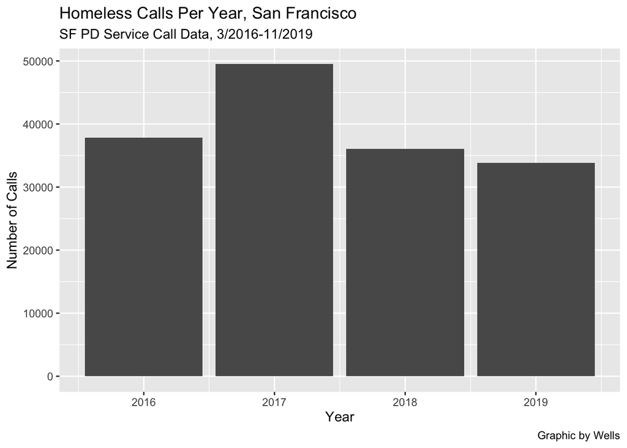

```r
ggplot(Years, aes(x = year, y = n)) +
  geom_bar(stat = "identity") +
  #coord_flip() +    #this makes it a horizontal bar chart instead of vertical
  labs(title = "Homeless Calls Per Year, San Francisco",
       subtitle = "SF PD Service Call Data, 3/2016-11/2019",
       caption = "Graphic by Wells",
       y="Number of Calls",
       x="Year")
```

A chart using a dplyr filtering language

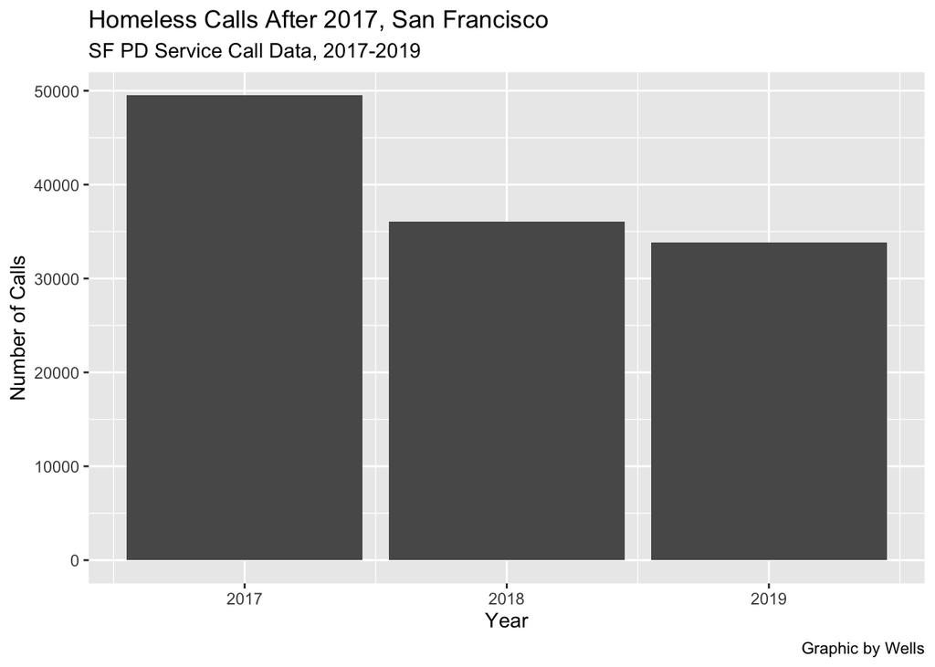

```r
Years %>%
  filter(year >= 2017) %>%
  ggplot(aes(x = year, y = n)) +
  geom_bar(stat = "identity") +
  #coord_flip() +    #this makes it a horizontal bar chart instead of vertical
  labs(title = "Homeless Calls After 2017, San Francisco",
       subtitle = "SF PD Service Call Data, 2017-2019",
       caption = "Graphic by Wells",
       y="Number of Calls",
       x="Year")
```

A more complex filter

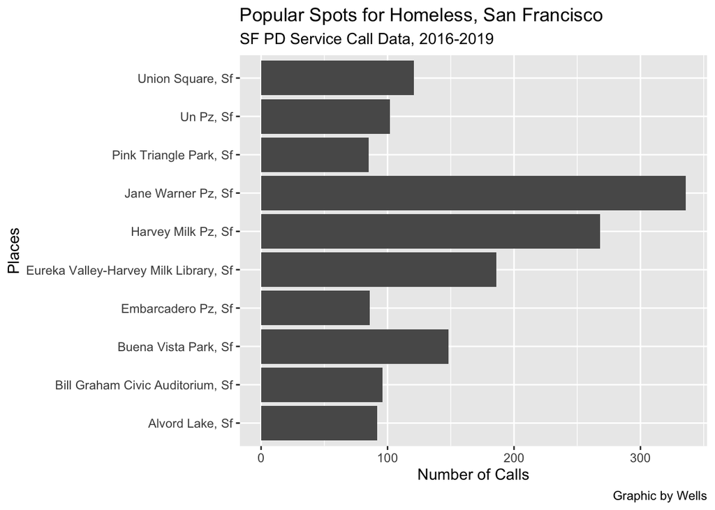

```r
SF %>%
  filter(!is.na(common_location)) %>%
  count(common_location) %>%
  top_n(10, n) %>%
  ggplot(aes(x = common_location, y = n)) +
  geom_bar(stat = "identity") +
  coord_flip() +    #this makes it a horizontal bar chart instead of vertical
  labs(title = "Popular Spots for Homeless, San Francisco",
       subtitle = "SF PD Service Call Data, 2016-2019",
       caption = "Graphic by Wells",
       y="Number of Calls",
       x="Places")
```

- **Question**: Chart the total dispositions.

Filter for at least 100 actions. Add color, export image to Blackboard.

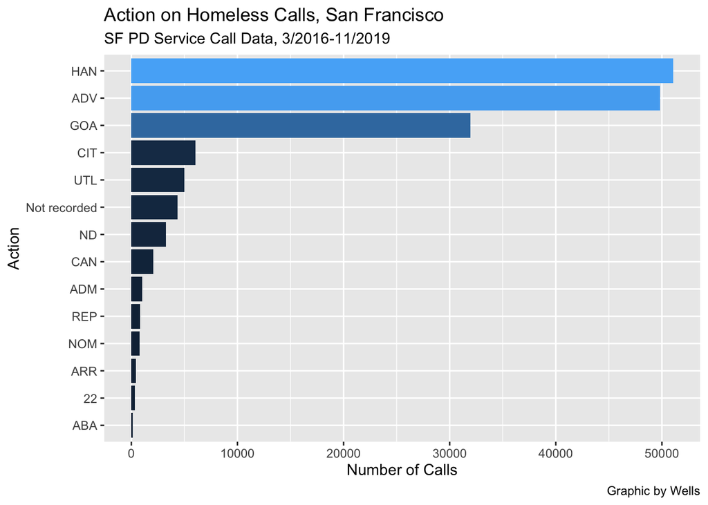

```r
Action %>%
  filter(n > 100) %>%
  ggplot(aes(x = reorder(disposition, n), y = n, fill=n)) +
  geom_bar(stat = "identity", show.legend = FALSE) +
  coord_flip() +    #this makes it a horizontal bar chart instead of vertical
  labs(title = "Action on Homeless Calls, San Francisco",
       subtitle = "SF PD Service Call Data, 3/2016-11/2019",
       caption = "Graphic by Wells",
       y="Number of Calls",
       x="Action")
```

# Part 3: Cleaning Dispositions

Making our charts less ugly

The disposition column is in cop-speak. We need to clean it up

Step #1: Duplicate the column you want to mess with

```r
SF$disposition1 <- SF$disposition
```

Rename specific strings. Example:

str_replace_all(test.vector, pattern=fixed(‘-’), replacement=fixed(‘:’) )

Details on string manipulation:

https://dereksonderegger.github.io/570L/13-string-manipulation.html

We can do this to replace ABA with “Abated”

```r
SF$disposition1 <- str_replace_all(SF$disposition1, pattern=fixed('ABA'), replacement=fixed('Abated') )
#Again with ADM
SF$disposition1 <- str_replace_all(SF$disposition1, pattern=fixed('ADM'), replacement=fixed('Admonished') )
```

We can do that 19 times. OR….

Look at this example using a lookup table to replace all the values  
https://stackoverflow.com/questions/50615116/renaming-character-variables-in-a-column-in-data-frame-r

Build a table to translate the Cop Speak to English:

```r
dispo_lkup <- c(ABA="Abated", ADM="Admonish", ADV="Advised", ARR="Arrest", CAN="Cancel", CSA="CPSA",
                CIT="Cited", CRM="Criminal", GOA="Gone", HAN="Handled", NCR="No_Criminal", ND="No_Dispo",
                NOM="No_Merit", PAS="PlaceSecure", REP="Report", SFD="Medical", UTL="Unfound", VAS="Vehicle_Secure", '22'="Cancel")

#22="Cancel" was handled differently because it is a numeric value: '22'="Cancel"

#This scans "disposition", finds ABA and replaces with Abated, finds ARR, replaces with Arrest, etc
SF$disposition1 <- as.character(dispo_lkup[SF$disposition])
```

Rerun Action with disposition1

```r
Action <- SF %>%
  count(disposition1) %>%
  arrange(desc(n))
```

Compare our renamed variables to the original disposition

```r
Action <- SF %>%
  count(disposition1, disposition) %>%
  arrange(desc(n))
```

We have codes not listed on the sheet

NA Not recorded 4339

Get rid of the space

```r
SF$disposition <- gsub("Not recorded", "Not_Recorded", SF$disposition)
```

Add to the list

```r
dispo_lkup <- c(ABA="Abated", ADM="Admonish", ADV="Advised", ARR="Arrest", CAN="Cancel", CSA="CPSA",
                CIT="Cited", CRM="Criminal", GOA="Gone", HAN="Handled", NCR="No_Criminal", ND="No_Dispo",
                NOM="No_Merit", PAS="PlaceSecure", REP="Report", SFD="Medical", UTL="Unfound",
                VAS="Vehicle_Secure", '22'="Cancel", Not_Recorded="NotRecorded")
```

Rerun

```r
Action <- SF %>%
  count(disposition1) %>%
  arrange(desc(n))
```

Chart Dispositions

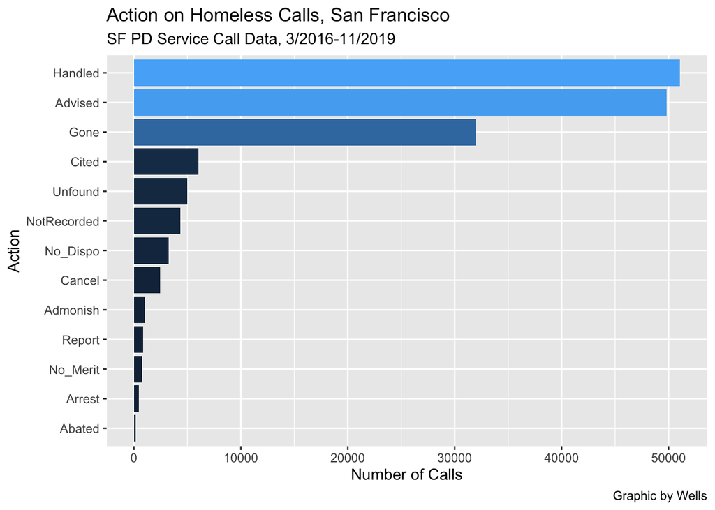

```r
Action %>%
  filter(n > 100) %>%
  ggplot(aes(x = reorder(disposition1, n), y = n, fill=n)) +
  geom_bar(stat = "identity", show.legend = FALSE) +
  coord_flip() +    #this makes it a horizontal bar chart instead of vertical
  labs(title = "Action on Homeless Calls, San Francisco",
       subtitle = "SF PD Service Call Data, 3/2016-11/2019",
       caption = "Graphic by Wells",
       y="Number of Calls",
       x="Action")
```

- **Parse out police codes from narrative: original_crime_type_name** Look at the Types table: some columns have one code, some have two. 919 2879 915 Sleeper 290

Some are separated by a slash 915/919 161

We need to unpack that - **Cleaning Sequence**

```r
#convert all text to lowercase
SF$crime1 <- tolower(SF$original_crime_type_name)
#Replace / with a space
SF$crime1 <- gsub("/", " ", SF$crime1)
#Replace '
SF$crime1 <- gsub("'", "", SF$crime1)
#fix space in homeless complaint
SF$crime1 <- gsub("homeless complaint", "homeless_complaint", SF$crime1)
#split data into two columns
SF <- separate(data = SF, col = crime1, into = c("crime2", "crime3", "crime4"), sep = " ", extra = "merge", fill = "right")
```

Look at the categories now

```r
Types2 <- SF %>% count(crime2) %>%
  group_by(crime2) %>%
  arrange(desc(n))
```

- **Question** Take the top 10 crime categories from Type2  
  Relabel them from the numeric radio codes into English  
  Using the technique earlier in “Build a table to translate the Cop Speak to English”  
  Relabel the offenses

```r
clean <- c(homeless_complaint="homeless_complaint", '915'="homeless_call", '919'="sit_lying", '920'="aggress_solicit", '915s'="homeless_call", '915x'="homeless_call", drugs="drugs", '601'="trespasser",
           poss="poss", aggressive="aggressive", '811'="intoxicated")
```

```r
SF$crime2 <- as.character(clean[SF$crime2])
```

Look at the categories now

```r
Types2 <- SF %>% count(crime2) %>%
  group_by(crime2) %>%
  arrange(desc(n))
```

- **Question:** Make a chart from your cleaned data

Basic chart but with a messed up x axis

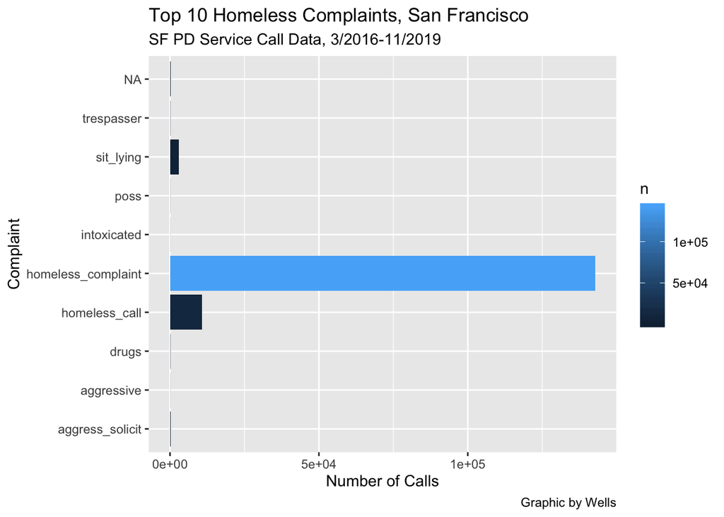

```r
Types2 %>%
  ggplot(aes(x = crime2, y = n, fill=n)) +
  geom_bar(stat = "identity") +
  coord_flip() +    #this makes it a horizontal bar chart instead of vertical
  labs(title = "Top 10 Homeless Complaints, San Francisco",
       subtitle = "SF PD Service Call Data, 3/2016-11/2019",
       caption = "Graphic by Wells",
       y="Number of Calls",
       x="Complaint")
```

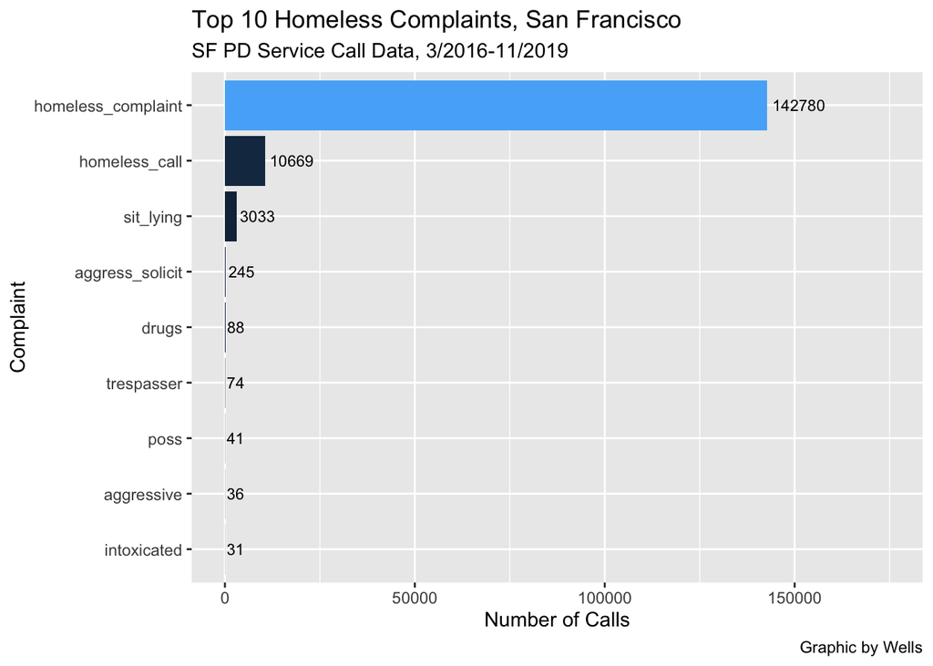

```r
Types2 %>%
  filter(!is.na(crime2)) %>%
  #filter(crime2!=" ") %>%  - a crude alternative to previous line!
  ggplot(aes(x = reorder(crime2, n), y = n, fill=n)) + #reorder sorts the bars
  geom_bar(stat = "identity", show.legend = FALSE) +
  geom_text(aes(label = n), hjust = -.1, size = 3) +
  scale_y_continuous(limits=c(0, 175000)) + #fixes scientific notation
  coord_flip() +    #this makes it a horizontal bar chart instead of vertical
  labs(title = "Top 10 Homeless Complaints, San Francisco",
       subtitle = "SF PD Service Call Data, 3/2016-11/2019",
       caption = "Graphic by Wells",
       y="Number of Calls",
       x="Complaint")
```

# Part 4: Using Mutate, Pct Calcs

mutate - Create new column(s) in the data, or change existing column(s).

mutate() adds new variables and preserves existing

Example: mtcars <- as.data.frame(mtcars) View(mtcars)

mtcars2 <- mtcars %>% as_tibble() %>% mutate( cyl2 = cyl * 2, cyl4 = cyl2 * 2 )

Process dates using lubidate

```r
SF <- SF %>%
  mutate(yearmo = format(call_date, "%Y-%m"))
```

Chart the number of calls by year and month

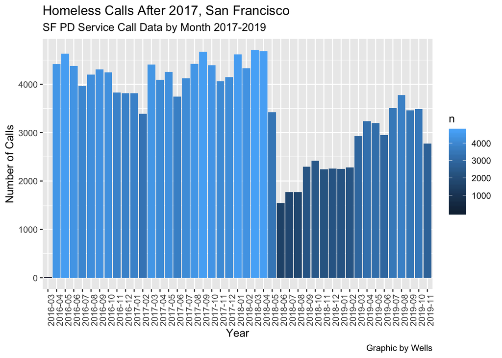

```r
SF %>%
  count(yearmo) %>%
  group_by(yearmo) %>%
  ggplot(aes(x = yearmo, y = n, fill=n)) +
  geom_bar(stat = "identity") +
  theme(axis.text.x = element_text(angle=90)) +
  #Changes angle of x axis labels
  #coord_flip() +    #this makes it a horizontal bar chart instead of vertical
  labs(title = "Homeless Calls After 2017, San Francisco",
       subtitle = "SF PD Service Call Data by Month 2017-2019",
       caption = "Graphic by Wells",
       y="Number of Calls",
       x="Year")
```

Percentage change per month

```r
PCT_CHG_CALLS <- SF %>%
  select(original_crime_type_name, disposition, address, call_date2, yearmo) %>%
  count(yearmo) %>%
  mutate(difference = (n-lag(n))) %>%
  mutate(pct_change = (difference/abs(lag(n)))*100)
```

- **Use grepl to search and tabulate**

grep and grepl: see ??grep

http://www.endmemo.com/program/R/grepl.php

Cleaning Sequence

```r
#convert all text to lowercase
SF$crime1 <- tolower(SF$original_crime_type_name)
```

- **Search for term, rename, put in new column called “cleaned”**

```r
x915 <- SF %>%
  filter(grepl ("915", original_crime_type_name)) %>%
  mutate(cleaned = "homeless_complaint")

x919 <- SF %>%
  filter(grepl ("919", original_crime_type_name)) %>%
  mutate(cleaned = "sitting_lying")

xsleep <- SF %>%
  filter(grepl ("sleep", original_crime_type_name)) %>%
  mutate(cleaned = "sleep")

xaggr <- SF %>%
  filter(grepl ("aggr", original_crime_type_name)) %>%
  mutate(cleaned = "aggressive")

xdrug <- SF %>%
  filter(grepl ("drug", original_crime_type_name)) %>%
  mutate(cleaned = "drug")

xhomeless <- SF %>%
  filter(grepl ("homeless_complaint", crime2)) %>%
  mutate(cleaned = "homeless_complaint")

#Moe, Brooke's Work:
xnoise <- SF %>%
  filter(grepl ("415", original_crime_type_name)) %>%
  mutate(cleaned = "noise")

xposs <- SF %>%
  filter(grepl ("poss", original_crime_type_name)) %>%
  mutate(cleaned = "possession")

xtrespasser <- SF %>%
  filter(grepl ("601", original_crime_type_name)) %>%
  mutate(cleaned = "trespasser")

xsolicit <- SF %>%
  filter(grepl ("920", original_crime_type_name)) %>%
  mutate(cleaned = "solicit")

xinterview <- SF %>%
  filter(grepl ("909", original_crime_type_name)) %>%
  mutate(cleaned = "interview")

xtent <- SF %>%
  filter(grepl ("tent", crime1)) %>%
  mutate(cleaned="tent")

xdog <- SF %>%
  filter(grepl ("dog", crime1)) %>%
  mutate(cleaned="dog")

xchopshop <- SF %>%
  filter(grepl ("chop shop", crime1)) %>%
  mutate(cleaned="chopshop")

xpanhandling <- SF %>%
  filter(grepl ("panhandling", crime1)) %>%
  mutate(cleaned="panhandling")

xmusic <- SF %>%
  filter(grepl ("music", crime1)) %>%
  mutate(cleaned="music")
```

Create new dataframe using rbind

```r
new_total <- rbind(xhomeless, x915, x919, xaggr, xdrug, xsleep, xnoise, xposs, xtrespasser, xsolicit, xinterview, xtent, xdog,
                   xchopshop, xpanhandling, xmusic)
```

Count it up!

```r
Total_Calls_Master <- new_total %>%
  count(cleaned) %>%
  arrange(desc(n))
#rename columns
colnames(Total_Calls_Master)[1:2] <- c("Complaints", "Number")
#export
write_csv(Total_Calls_Master, "Total_Calls_Master.csv")
```

Make into html table

```r
#install.packages("kableExtra")
library(kableExtra)
#This makes html tables called "kables"
Total_Calls_Master %>%
  kable() %>%
  kable_styling("striped")
```

| Complaints | Number |
| --- | --- |
| homeless_complaint | 153895 |
| sitting_lying | 3282 |
| solicit | 262 |
| trespasser | 100 |
| sleep | 77 |
| interview | 75 |
| drug | 52 |
| noise | 27 |
| aggressive | 18 |
| dog | 12 |
| tent | 9 |
| music | 8 |
| chopshop | 7 |
| panhandling | 5 |
| possession | 5 |

Export from Viewer as .png

- **Task: Tabulate complaints by day of the week**

https://github.com/profrobwells/Data-Analysis-Class-Jour-405v-5003/blob/master/Readings/dealing-with-dates.pdf

```r
SF <- SF %>%
  mutate(weekday = wday(call_date, label=TRUE, abbr=FALSE))
```

Build a summary table with the days of the week with the greatest number of calls. Create a graphic. Then build a table to see if the complaints vary by day

Below from Matthew Moore, Katy Seiter, Wells edited

```r
SF <- SF %>%
  mutate(weekday = wday(call_date, label=TRUE, abbr=FALSE))

Weekday_Count <- SF %>%
  select(weekday, crime_id) %>%
  count(weekday) %>%
  arrange(desc(n))
```

Graphic of calls by weekdays

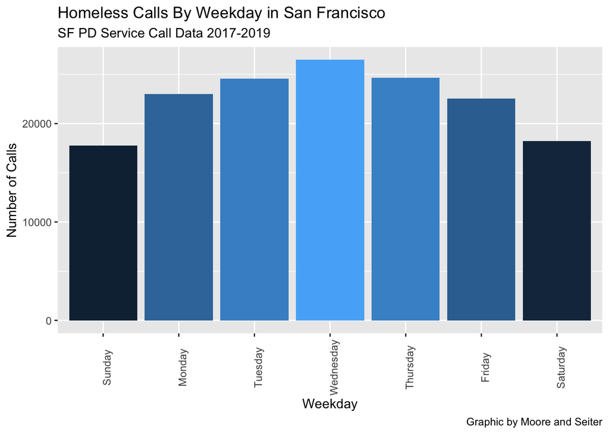

```r
Weekday_Count %>%
  ggplot(aes(x = weekday, y = n, fill=n)) +
  geom_bar(stat = "identity", show.legend = FALSE) +
  theme(axis.text.x = element_text(angle=90)) +
  #Changes angle of x axis labels
  #coord_flip() +    #this makes it a horizontal bar chart instead of vertical
  labs(title = "Homeless Calls By Weekday in San Francisco",
       subtitle = "SF PD Service Call Data 2017-2019",
       caption = "Graphic by Moore and Seiter",
       y="Number of Calls",
       x="Weekday")
```

Create a Bubble graphic

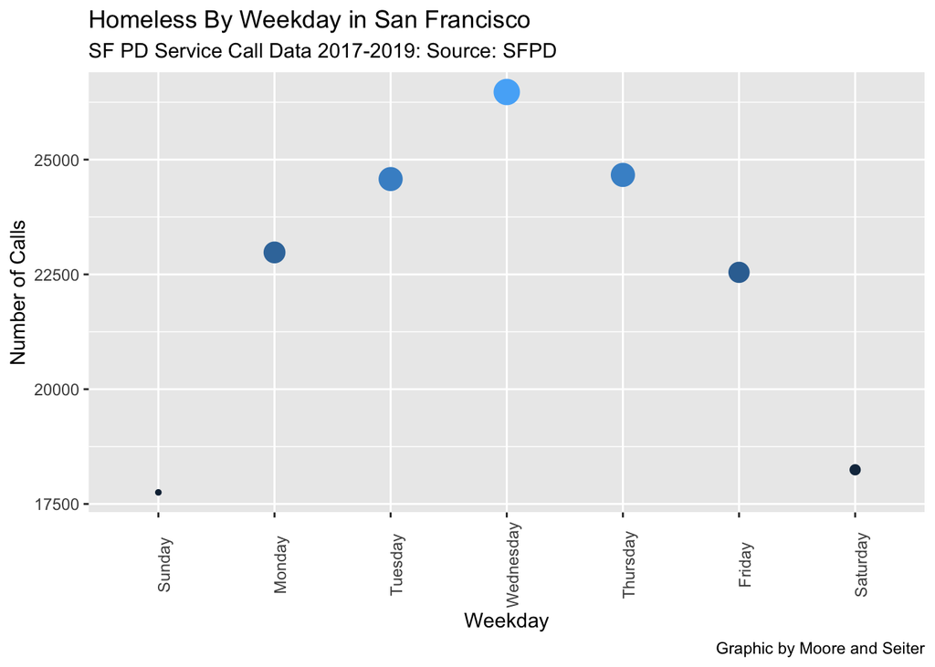

```r
ggplot(data = Weekday_Count) +
  geom_point(mapping = aes(x = weekday, y = n, size = n, color = n), show.legend = FALSE) +
  theme(axis.text.x = element_text(angle=90)) +
  labs(title = "Homeless By Weekday in San Francisco",
       subtitle = "SF PD Service Call Data 2017-2019: Source: SFPD",
       caption = "Graphic by Moore and Seiter",
       y="Number of Calls",
       x="Weekday")
```

Improved bubble chart

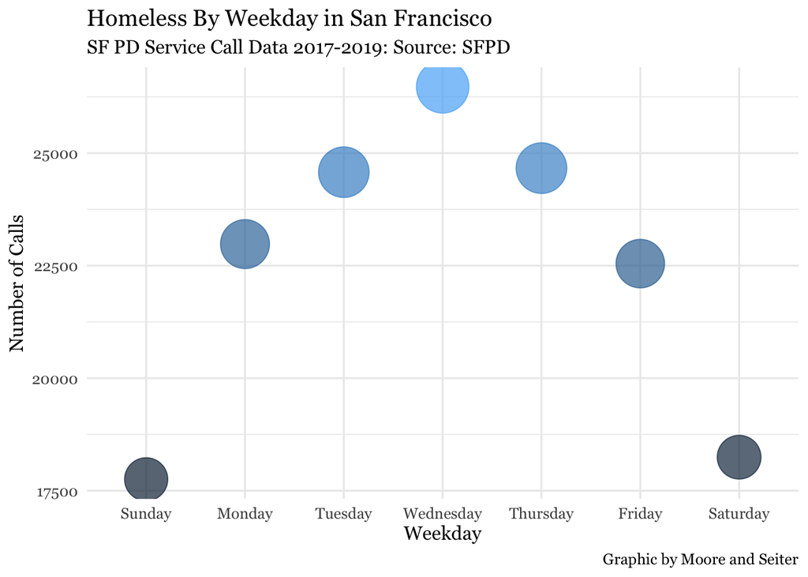

```r
ggplot(Weekday_Count, aes(x = weekday, y = n)) +
  xlab("Weekday") +
  ylab("Number of Calls") +
  theme_minimal(base_size = 12, base_family = "Georgia") +
  geom_point(aes(size = n, color = n), alpha = 0.7, show.legend = FALSE) +
  scale_size_area(guide = FALSE, max_size = 15) +
  labs(title = "Homeless By Weekday in San Francisco",
       subtitle = "SF PD Service Call Data 2017-2019: Source: SFPD",
       caption = "Graphic by Moore and Seiter")
```

- **Task #3: Calls vs Dispositions**

What calls resulted in arrests? What calls resulted in citations?

```r
Action2 <- SF %>%
  select(crime_id, original_crime_type_name, disposition)
```

We need to pair the crime type and disposition and then count them

From Michael Adkison:

```r
callsarrest <- Action2 %>%
  filter(grepl("ARR", disposition)) %>%
  mutate(cleaned = "Arrest")
```

To quickly format into percents, load formattable

```r
#install.packages("formattable")
library(formattable)

callsarrest2 <- callsarrest %>%
  arrange(original_crime_type_name, disposition) %>%
  count(original_crime_type_name) %>%
#mutate(PctTotal = (n/441)) %>%
  arrange(desc(n))

colnames(callsarrest2)[1:2] <- c("Complaints", "Arrests")
```

Build a table to translate the Cop Speak to English:

```r
clean <- c('Homeless Complaint'="homeless_complaint", homeless_complaint="homeless_complaint", '915'="homeless_complaint",
           '919'="Sit_lying", '920'="Aggress_solicit", '915s'="homeless_complaint", '915x'="homeless_complaint",
           drugs="drugs", '601'="trespasser", poss="poss", aggressive="aggressive", '811'="intoxicated",
           'Drugs / 915'="Drugs", 'Drugs/915'="Drugs")
```

This scans “disposition”, finds ABA and replaces with Abated, finds ARR, replaces with Arrest, etc callsarrest2$Complaints <- as.character(clean[callsarrest2$Complaints])

```r
callsarrest3 <- callsarrest2 %>%
  select(Complaints, Arrests) %>%
  group_by(Complaints) %>%
  summarise(total = sum(Arrests)) %>%
  mutate(PctTotal = (total/441)) %>%
  arrange(desc(total))

colnames(callsarrest3)[2] <- "Arrests"
callsarrest3$PctTotal <- percent(callsarrest3$PctTotal)

#This makes kables
callsarrest3 %>%
  kable() %>%
  kable_styling("striped")
```

| Complaints | Arrests | PctTotal |
| --- | --- | --- |
| Homeless Complaint | 412 | 93.42% |
| 915 | 19 | 4.31% |
| 919 | 4 | 0.91% |
| 920 | 2 | 0.45% |
| 601 / 915 | 1 | 0.23% |
| 915 / 909 | 1 | 0.23% |
| Drugs / 915 | 1 | 0.23% |
| Drugs/915 | 1 | 0.23% |

# Part 5: Trends over time

- **Question**: What were the common days for arrests?

```r
SF %>%
  select(weekday, crime_id, disposition) %>%
  filter(grepl("ARR", disposition)) %>%
  count(weekday)
```

```
## # A tibble: 7 x 2
##   weekday       n
##   <ord>     <int>
## 1 Sunday       47
## 2 Monday       63
## 3 Tuesday      79
## 4 Wednesday    77
## 5 Thursday     74
## 6 Friday       56
## 7 Saturday     45
```

Make bubble chart

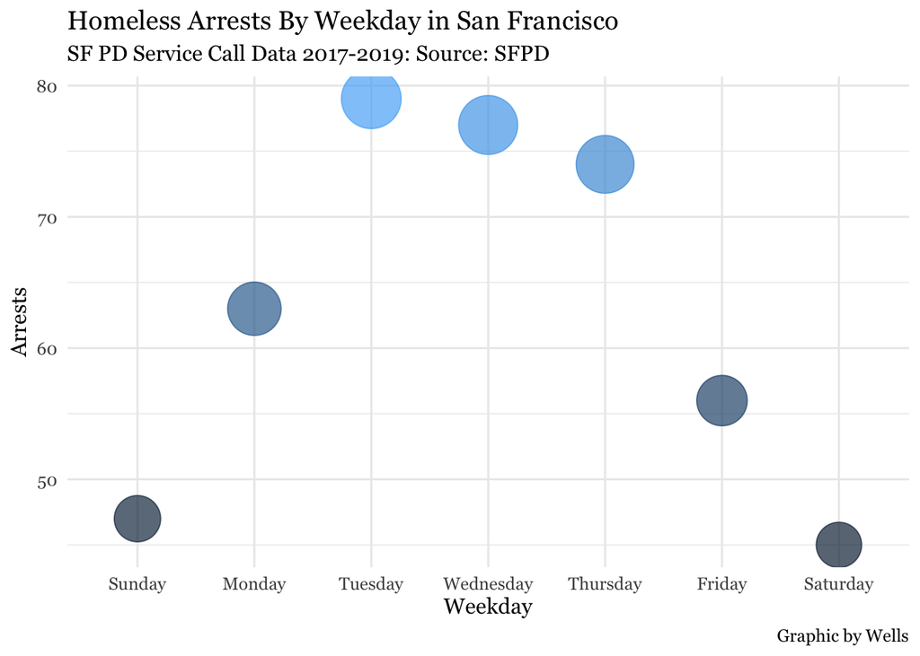

```r
SF %>%
  select(weekday, crime_id, disposition) %>%
  filter(grepl("ARR", disposition)) %>%
  count(weekday) %>%
  ggplot(aes(x = weekday, y = n)) +
  xlab("Weekday") +
  ylab("Arrests") +
  theme_minimal(base_size = 12, base_family = "Georgia") +
  geom_point(aes(size = n, color = n), alpha = 0.7, show.legend = FALSE) +
  scale_size_area(guide = FALSE, max_size = 15) +
  labs(title = "Homeless Arrests By Weekday in San Francisco",
       subtitle = "SF PD Service Call Data 2017-2019: Source: SFPD",
       caption = "Graphic by Wells")
```

- **Question**: What is the trend for arrests over the time period?

[figure not shown]

```r
SF %>%
  filter(grepl("ARR", disposition)) %>%
  count(yearmo) %>%
  group_by(yearmo) %>%
  ggplot(aes(x = yearmo, y = n, fill=n)) +
  geom_bar(stat = "identity", show.legend = FALSE) +
  geom_smooth(method = lm, se=FALSE, color = "red") +
  theme(axis.text.x = element_text(angle=90)) +
  #Changes angle of x axis labels
  #coord_flip() +    #this makes it a horizontal bar chart instead of vertical
  labs(title = "Arrest Trends on Homeless Calls in San Francisco",
       subtitle = "Arrests Based on SF PD Service Call Data by Month 2017-2019",
       caption = "Graphic by Wells",
       y="Number of Calls",
       x="Year")
```

- **Question**: What are the hours most likely for complaints?

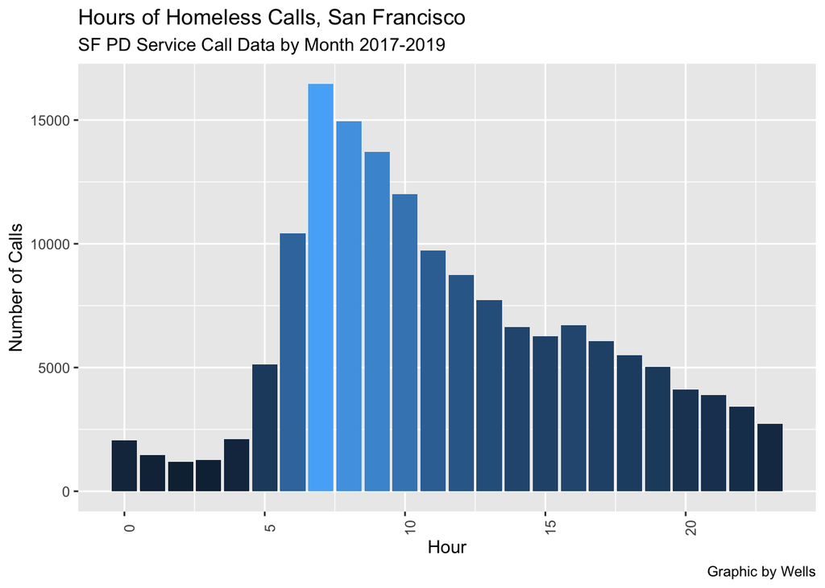

```r
#format to hours
SF$hour <- hour(SF$call_date_time)

SF %>%
  count(hour) %>%
  group_by(hour) %>%
  ggplot(aes(x = hour, y = n, fill=n)) +
  geom_bar(stat = "identity", show.legend = FALSE) +
  theme(axis.text.x = element_text(angle=90)) +
  #Changes angle of x axis labels
  #coord_flip() +    #this makes it a horizontal bar chart instead of vertical
  labs(title = "Hours of Homeless Calls, San Francisco",
       subtitle = "SF PD Service Call Data by Month 2017-2019",
       caption = "Graphic by Wells",
       y="Number of Calls",
       x="Hour")
```

- **Question**: Examine some of the charting options on this tutorial and adapt them to this data using any chart you want # https://paldhous.github.io/wcsj/2017/

# –30–